# RepDataPeer1

Esteban R. Freyre

9/14/2019

```r
knitr::opts_chunk$set(echo = TRUE)
```

Introduction

It is now possible to collect a large amount of data about personal movement using activity monitoring devices such as a Fitbit, Nike Fuelband, or Jawbone Up. These type of devices are part of the “quantified self” movement – a group of enthusiasts who take measurements about themselves regularly to improve their health, to find patterns in their behavior, or because they are tech geeks. But these data remain under-utilized both because the raw data are hard to obtain and there is a lack of statistical methods and software for processing and interpreting the data.

This assignment makes use of data from a personal activity monitoring device. This device collects data at 5 minute intervals through out the day. The data consists of two months of data from an anonymous individual collected during the months of October and November, 2012 and include the number of steps taken in 5 minute intervals each day.

### Loading and preprocessing the data

```r
library(data.table)
```

Code for reading in the dataset and/or processing the data download data set from “https://d396qusza40orc.cloudfront.net/repdata%2Fdata%2Factivity.zip”

```r
activity<-read.table("activity.csv",sep = ",",header = TRUE,colClasses = c("numeric","POSIXct","numeric"))
activity<-data.table(activity)
str(activity)
```

```
## Classes 'data.table' and 'data.frame':   17568 obs. of  3 variables:
##  $ steps   : num  NA NA NA NA NA NA NA NA NA NA ...
##  $ date    : POSIXct, format: "2012-10-01" "2012-10-01" ...
##  $ interval: num  0 5 10 15 20 25 30 35 40 45 ...
##  - attr(*, ".internal.selfref")=<externalptr>
```

```r
summary(activity)
```

```
##      steps             date               interval
##  Min.   :  0.00   Min.   :2012-10-01   Min.   :   0.0
##  1st Qu.:  0.00   1st Qu.:2012-10-16   1st Qu.: 588.8
##  Median :  0.00   Median :2012-10-31   Median :1177.5
##  Mean   : 37.38   Mean   :2012-10-31   Mean   :1177.5
##  3rd Qu.: 12.00   3rd Qu.:2012-11-15   3rd Qu.:1766.2
##  Max.   :806.00   Max.   :2012-11-30   Max.   :2355.0
##  NA's   :2304
```

```r
class(activity)
```

```
## [1] "data.table" "data.frame"
```

Percentage of NAs in the sample is 13.11%

```r
mean(is.na(activity$steps))
```

```
## [1] 0.1311475
```

```r
head(activity,4)
```

```
##    steps       date interval
## 1:    NA 2012-10-01        0
## 2:    NA 2012-10-01        5
## 3:    NA 2012-10-01       10
## 4:    NA 2012-10-01       15
```

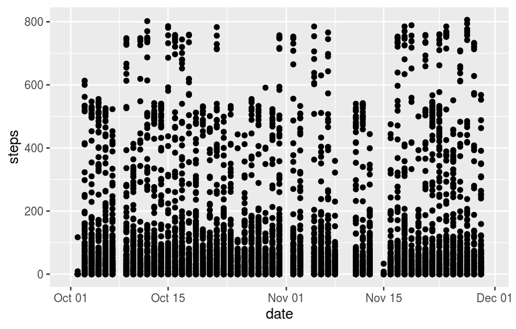

```r
library(ggplot2)
qplot(date,steps, data=activity)
```

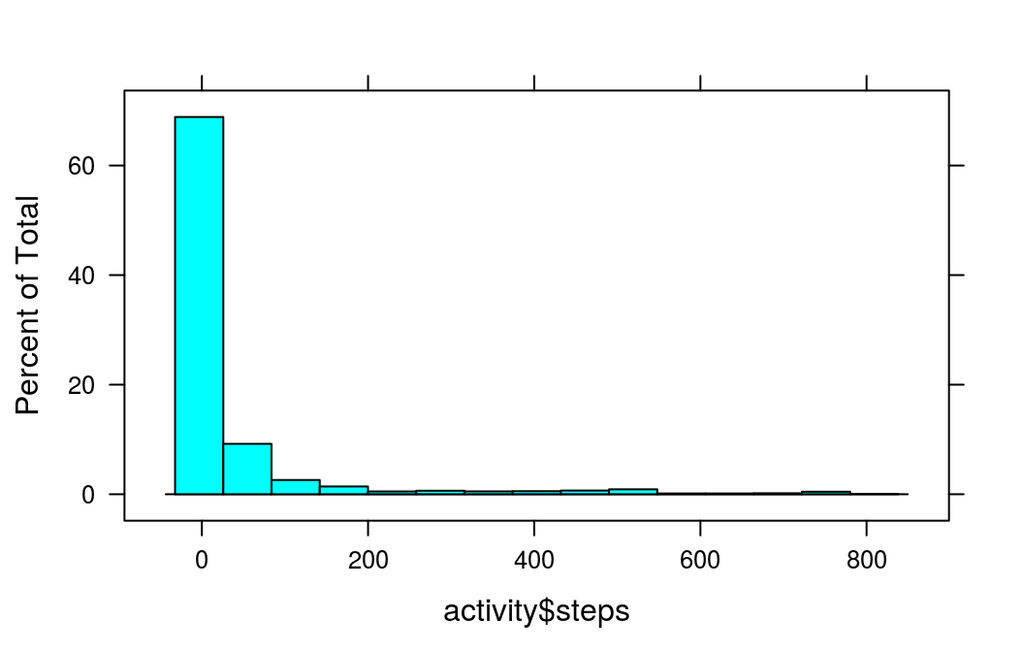

```r
library(lattice)
histogram(activity$steps,activity$date)
```

Calculate the total number of steps taken per day

```r
ans1<-activity[, .(dailytotal=sum(steps),dailymean=mean(steps)), by = date]
head(ans1)
```

```
##          date dailytotal dailymean
## 1: 2012-10-01         NA        NA
## 2: 2012-10-02        126   0.43750
## 3: 2012-10-03      11352  39.41667
## 4: 2012-10-04      12116  42.06944
## 5: 2012-10-05      13294  46.15972
## 6: 2012-10-06      15420  53.54167
```

```r
summary(ans1)
```

```
##       date              dailytotal      dailymean
##  Min.   :2012-10-01   Min.   :   41   Min.   : 0.1424
##  1st Qu.:2012-10-16   1st Qu.: 8841   1st Qu.:30.6979
##  Median :2012-10-31   Median :10765   Median :37.3785
##  Mean   :2012-10-31   Mean   :10766   Mean   :37.3826
##  3rd Qu.:2012-11-15   3rd Qu.:13294   3rd Qu.:46.1597
##  Max.   :2012-11-30   Max.   :21194   Max.   :73.5903
##                       NA's   :8       NA's   :8
```

Histogram of the total number of steps taken each day

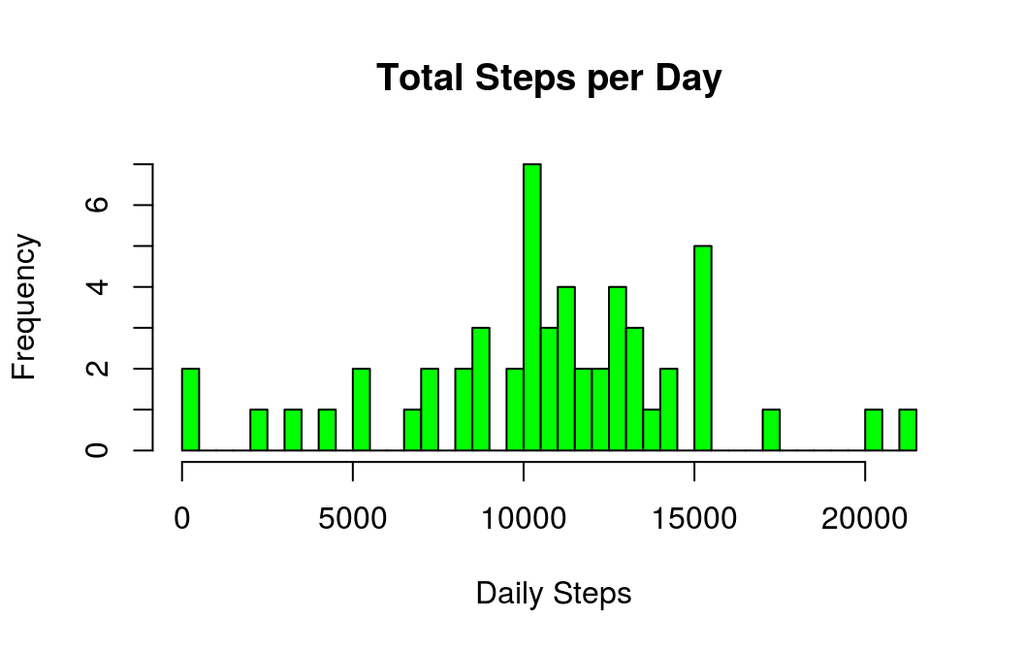

```r
hist(ans1$dailytotal, col="green", breaks = 60, main = "Total Steps per Day",xlab = " Daily Steps")
```

### What is mean total number of steps taken per day?

The mean and median number of steps taken each day are almost the same around 37.38

### What is the average daily activity pattern?

Time series plot of the average number of steps taken

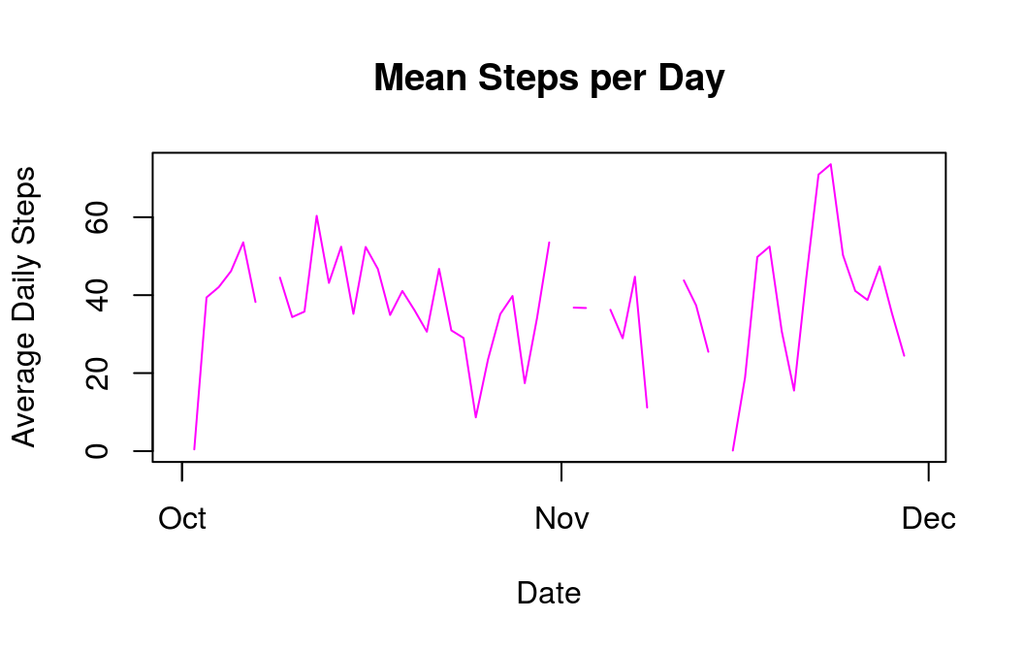

```r
with(ans1,plot(date,dailymean,type="l",col="magenta",main = "Mean Steps per Day",xlab = "Date",ylab = "Average Daily Steps"))
```

Make a time series plot (i.e. type = “l”) of the 5-minute interval (x-axis) and the average number of steps taken, averaged across all days (y-axis)

```r
ans2<-activity[,  lapply(.SD, mean,na.rm=TRUE), by = interval,.SDcols=c("steps")]
head(ans2)
```

```
##    interval     steps
## 1:        0 1.7169811
## 2:        5 0.3396226
## 3:       10 0.1320755
## 4:       15 0.1509434
## 5:       20 0.0754717
## 6:       25 2.0943396
```

```r
summary(ans2)
```

```
##     interval          steps
##  Min.   :   0.0   Min.   :  0.000
##  1st Qu.: 588.8   1st Qu.:  2.486
##  Median :1177.5   Median : 34.113
##  Mean   :1177.5   Mean   : 37.383
##  3rd Qu.:1766.2   3rd Qu.: 52.835
##  Max.   :2355.0   Max.   :206.170
```

Time series plot of the 5 minute average number of steps taken

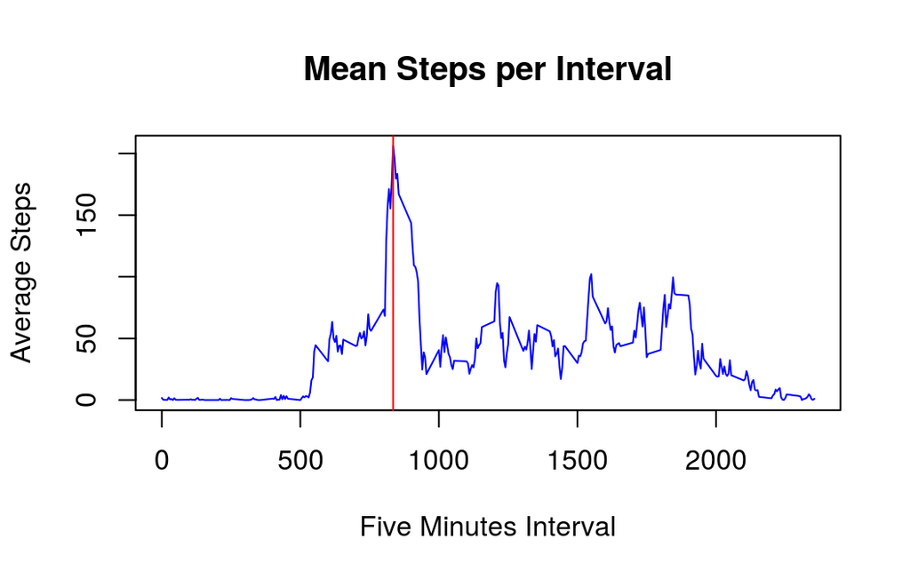

```r
with(ans2,plot(interval,steps,type="l",col="blue",main = "Mean Steps per Interval",xlab = "Five Minutes Interval",ylab = "Average Steps"))
abline(v=835, col="red")
```

The 5-minute interval that, on average, contains the maximum number of steps is interval 835. See graphic by intervals above.

```r
maxinter<-activity[, lapply(.SD, mean,na.rm=TRUE), by = interval,.SDcols=c("steps")][order(-steps)]
head(maxinter,10)
```

```
##     interval    steps
##  1:      835 206.1698
##  2:      840 195.9245
##  3:      850 183.3962
##  4:      845 179.5660
##  5:      830 177.3019
##  6:      820 171.1509
##  7:      855 167.0189
##  8:      815 157.5283
##  9:      825 155.3962
## 10:      900 143.4528
```

### Imputing missing values

Calculate and report the total number of missing values in the datase

```r
rbind("Total Number of NAs:"=sum(is.na(activity)))
```

```
##                      [,1]
## Total Number of NAs: 2304
```

Devise a strategy for filling in all of the missing values in the dataset. The strategy does not need to be sophisticated. For sake of simpleness a shrincage aproach wil be used, after working on the weekday factor variable question.

### Are there differences in activity patterns between weekdays and weekends?

Create a new factor variable in the dataset with two levels – “weekday” and “weekend” indicating whether a given date is a weekday or weekend day.

```r
weekday1<-activity$date
str(weekday1)
```

```
##  POSIXct[1:17568], format: "2012-10-01" "2012-10-01" "2012-10-01" "2012-10-01" "2012-10-01" ...
```

```r
weekday2<-weekdays.POSIXt(weekday1)
str(weekday2)
```

```
##  chr [1:17568] "Monday" "Monday" "Monday" "Monday" "Monday" "Monday" ...
```

```r
tail(weekday2)
```

```
## [1] "Friday" "Friday" "Friday" "Friday" "Friday" "Friday"
```

```r
weekday2<-gsub("Saturday|Sunday","weekend",weekday2)
weekday2<-gsub("Monday|Tuesday|Wednesday|Thursday|Friday","weekday",weekday2)
str(weekday2)
```

```
##  chr [1:17568] "weekday" "weekday" "weekday" "weekday" "weekday" ...
```

```r
weekday3<-as.factor(weekday2)
str(weekday3)
```

```
##  Factor w/ 2 levels "weekday","weekend": 1 1 1 1 1 1 1 1 1 1 ...
```

```r
activity$weekday<-weekday3
str(activity)
```

```
## Classes 'data.table' and 'data.frame':   17568 obs. of  4 variables:
##  $ steps   : num  NA NA NA NA NA NA NA NA NA NA ...
##  $ date    : POSIXct, format: "2012-10-01" "2012-10-01" ...
##  $ interval: num  0 5 10 15 20 25 30 35 40 45 ...
##  $ weekday : Factor w/ 2 levels "weekday","weekend": 1 1 1 1 1 1 1 1 1 1 ...
##  - attr(*, ".internal.selfref")=<externalptr>
```

```r
summary(activity)
```

```
##      steps             date               interval         weekday
##  Min.   :  0.00   Min.   :2012-10-01   Min.   :   0.0   weekday:12960
##  1st Qu.:  0.00   1st Qu.:2012-10-16   1st Qu.: 588.8   weekend: 4608
##  Median :  0.00   Median :2012-10-31   Median :1177.5
##  Mean   : 37.38   Mean   :2012-10-31   Mean   :1177.5
##  3rd Qu.: 12.00   3rd Qu.:2012-11-15   3rd Qu.:1766.2
##  Max.   :806.00   Max.   :2012-11-30   Max.   :2355.0
##  NA's   :2304
```

```r
sum(is.na(activity))
```

```
## [1] 2304
```

```r
averages<-activity[,lapply(.SD, mean,na.rm=TRUE),by =weekday,.SDcols=c("steps")]
averages
```

```
##    weekday    steps
## 1: weekday 35.33796
## 2: weekend 43.07837
```

First,in order to avoid in-place modification we make a copy of the previous data.table with NAs.

```r
DT2 = copy(activity)
```

```r
DT2[is.na(DT2)]<-c(35.34,43.08)
sum(is.na(DT2))
```

```
## [1] 0
```

```r
head(DT2)
```

```
##    steps       date interval weekday
## 1: 35.34 2012-10-01        0 weekday
## 2: 43.08 2012-10-01        5 weekday
## 3: 35.34 2012-10-01       10 weekday
## 4: 43.08 2012-10-01       15 weekday
## 5: 35.34 2012-10-01       20 weekday
## 6: 43.08 2012-10-01       25 weekday
```

Make a histogram of the total number of steps taken each day and Calculate and report the mean and median total number of steps taken per day. Do these values differ from the estimates from the first part of the assignment? What is the impact of imputing missing data on the estimates of the total daily number of steps?

Changes in daily steps per day comparison

```r
ans4<-DT2[,.(dailytotal= sum(steps),dailymean=mean(steps)),by=date]
head(ans4)
```

```
##          date dailytotal dailymean
## 1: 2012-10-01   11292.48  39.21000
## 2: 2012-10-02     126.00   0.43750
## 3: 2012-10-03   11352.00  39.41667
## 4: 2012-10-04   12116.00  42.06944
## 5: 2012-10-05   13294.00  46.15972
## 6: 2012-10-06   15420.00  53.54167
```

```r
summary(ans4)
```

```
##       date              dailytotal      dailymean
##  Min.   :2012-10-01   Min.   :   41   Min.   : 0.1424
##  1st Qu.:2012-10-16   1st Qu.: 9819   1st Qu.:34.0938
##  Median :2012-10-31   Median :11292   Median :39.2100
##  Mean   :2012-10-31   Mean   :10835   Mean   :37.6223
##  3rd Qu.:2012-11-15   3rd Qu.:12811   3rd Qu.:44.4826
##  Max.   :2012-11-30   Max.   :21194   Max.   :73.5903
```

Histogram of the total number of steps taken each day

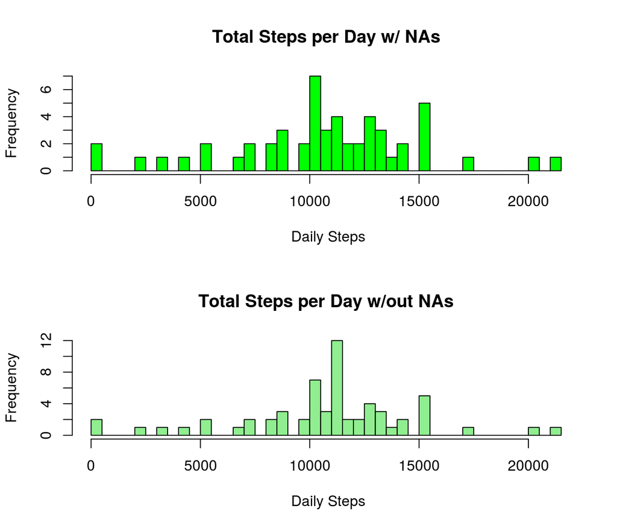

```r
par(mfcol=c(2,1))
hist(ans1$dailytotal, col="green", breaks = 60, main = "Total Steps per Day w/ NAs",xlab = " Daily Steps")
hist(ans4$dailytotal, col="lightgreen", breaks = 60, main = "Total Steps per Day w/out NAs",xlab = " Daily Steps")
```

calculate and report the difference in the mean and median lectures. The mean and the median difference increases.Being now the media 39.21 and the mean 37.62.

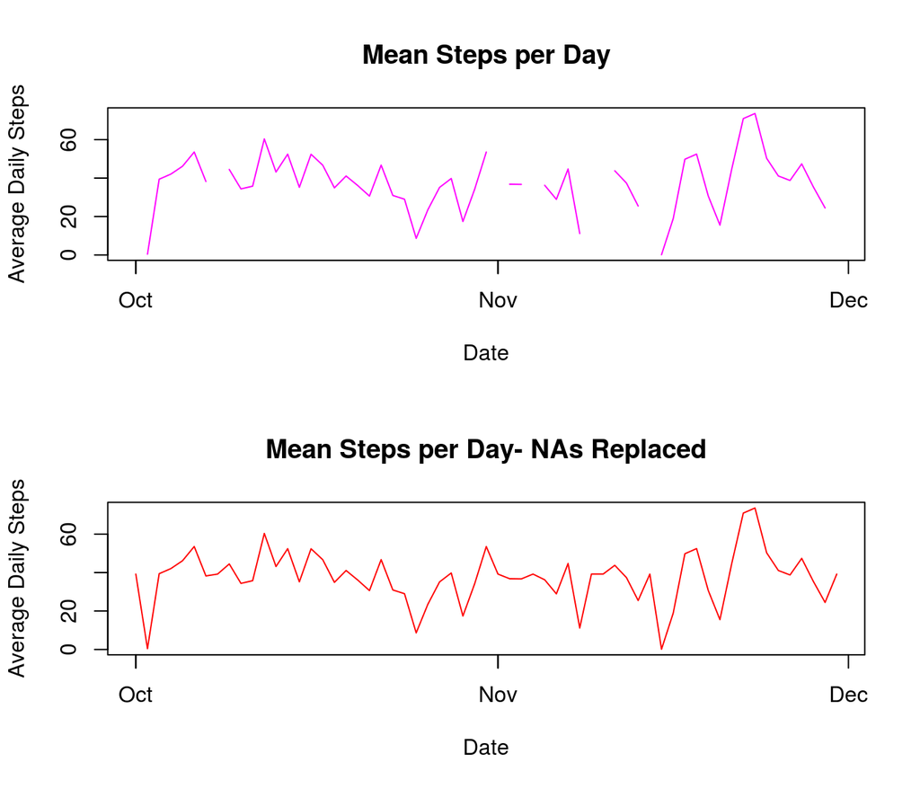

```r
par(mfcol=c(2,1))
with(ans1,plot(date,dailymean,type="l",col="magenta",main = "Mean Steps per Day",xlab = "Date",ylab = "Average Daily Steps"))
with(ans4,plot(date,dailymean,type="l",col="red",main = "Mean Steps per Day- NAs Replaced",xlab = "Date",ylab = "Average Daily Steps"))
```

Make a panel plot containing a time series plot (i.e. type = “l” of the 5-minute interval (x-axis) and the average number of steps taken, averaged across all weekday days or weekend days (y-axis).

```r
ans7<-DT2[,.(mean_steps=mean(steps)),by =.(interval,weekday)]
head(ans7)
```

```
##    interval weekday mean_steps
## 1:        0 weekday   6.734222
## 2:        5 weekday   6.144000
## 3:       10 weekday   4.867556
## 4:       15 weekday   5.921778
## 5:       20 weekday   4.800889
## 6:       25 weekday   7.055111
```

```r
summary(ans7)
```

```
##     interval         weekday      mean_steps
##  Min.   :   0.0   weekday:288   Min.   :  4.418
##  1st Qu.: 588.8   weekend:288   1st Qu.:  6.731
##  Median :1177.5                 Median : 28.085
##  Mean   :1177.5                 Mean   : 39.225
##  3rd Qu.:1766.2                 3rd Qu.: 59.533
##  Max.   :2355.0                 Max.   :208.633
```

Time series plot of the 5 min average number of steps taken with weekday as factor.

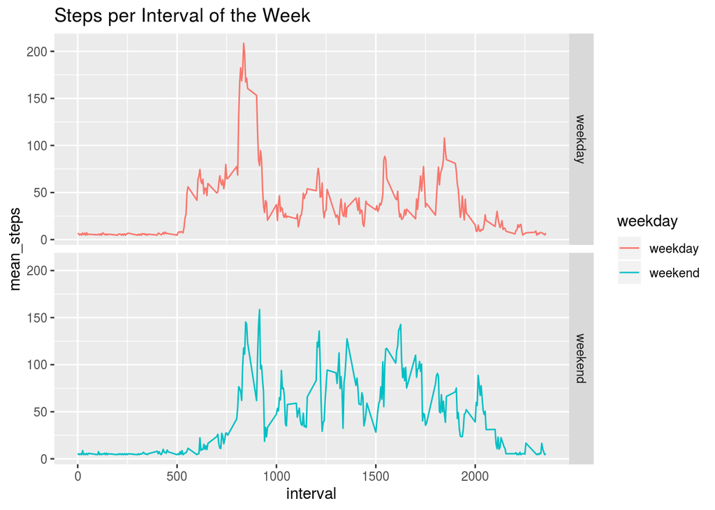

```r
ggplot(ans7)+geom_line(aes(x=interval,y=mean_steps,color = weekday))+facet_grid(weekday~.)+labs(title ="Steps per Interval of the Week")
```